# Chick Weight Analysis

Author

GROUP 5 - John Z, Andrew C, Angelo R, Liam W

# 1 Introduction

This project investigates the relationship between weight gain in chicks and various predictors using the `ChickWeight` dataset. The dependent variable is `weight`, while potential predictors include `Time`, `Diet`, and other engineered variables. It is hypothesized that both `Time` and `Diet` have significant effects on `weight`, with `Time` positively influencing weight and `Diet` having varying impacts depending on its composition.

A DAG visualizing these relationships is created below:

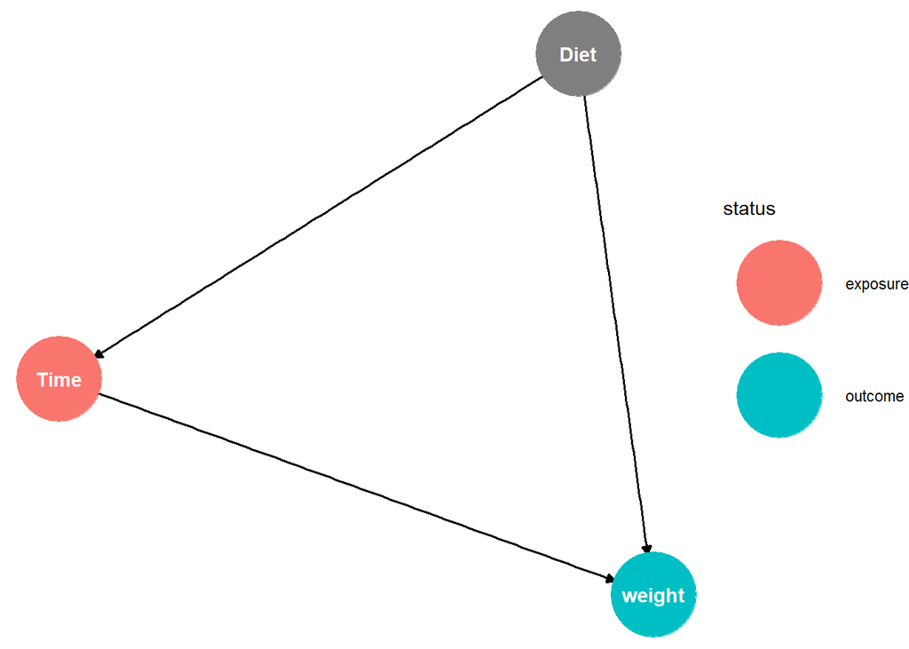

```r
library(tidyverse)
library(ggdag)
set.seed(123)
dagify(weight ~ Time + Diet,
       Time ~ Diet,
       outcome = "weight",
       exposure = "Time") |>
ggdag_status(node_size = 22) + theme_void()
```

# 2 Data

The data for this project comes from the built-in `ChickWeight` dataset in R. The dataset contains observations of chicks’ weights over time under different dietary conditions. It includes the following variables:

- `weight`: Weight of the chick
- `Time`: Time in days
- `Diet`: Diet type (categorical)

The dataset is inspected for completeness and size, ensuring it meets project criteria.

```r
data("ChickWeight")
summary(ChickWeight)
```

```
     weight           Time           Chick     Diet
 Min.   : 35.0   Min.   : 0.00   13     : 12   1:220
 1st Qu.: 63.0   1st Qu.: 4.00   9      : 12   2:120
 Median :103.0   Median :10.00   20     : 12   3:120
 Mean   :121.8   Mean   :10.72   10     : 12   4:118
 3rd Qu.:163.8   3rd Qu.:16.00   17     : 12
 Max.   :373.0   Max.   :21.00   19     : 12
                                 (Other):506
```

```r
dim(ChickWeight)
```

```
[1] 578   4
```

# 3 Data Cleaning and Engineering

The dataset is cleaned, and new variables are engineered where necessary. Below is the preprocessing step:

```r
library(janitor)
DataChick <- ChickWeight |>
  clean_names() |>
  filter(!is.na(weight))

head(DataChick)
```

```
  weight time chick diet
1     42    0     1    1
2     51    2     1    1
3     59    4     1    1
4     64    6     1    1
5     76    8     1    1
6     93   10     1    1
```

# 4 Exploratory Data Analysis (EDA)

An EDA is performed to understand variable distributions and relationships.

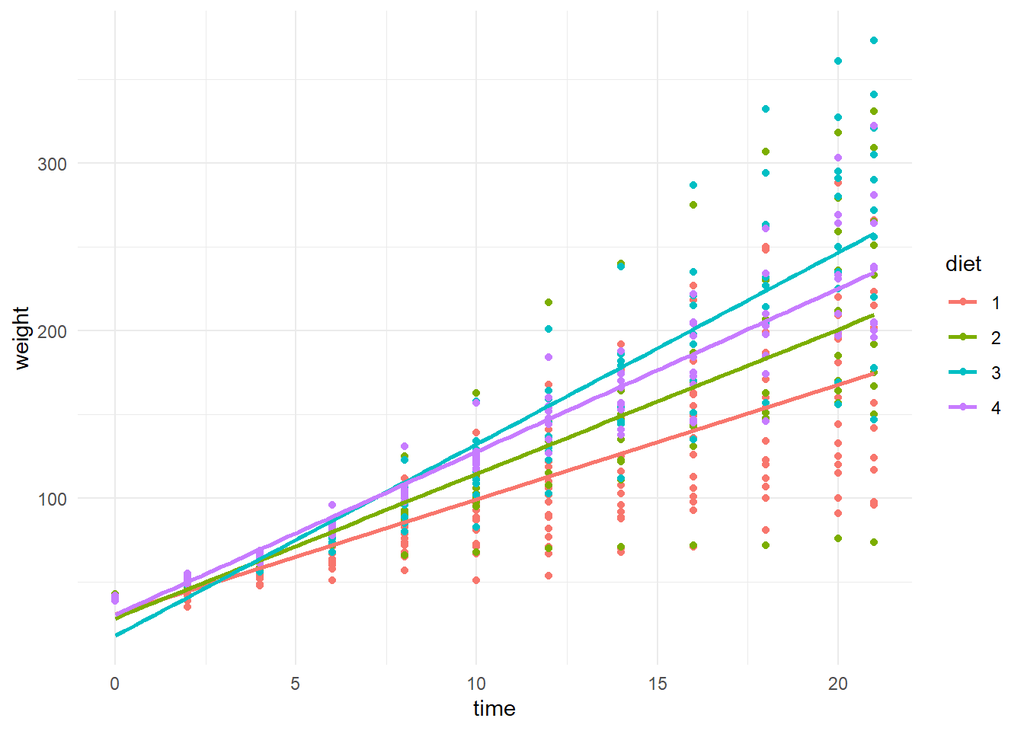

```r
ggplot(DataChick, aes(x = time, y = weight, color = diet)) +
  geom_point() +
  geom_smooth(method = "lm", se = FALSE) +
  theme_minimal()
```

# 5 Pairwise Correlation of Continuous Variables

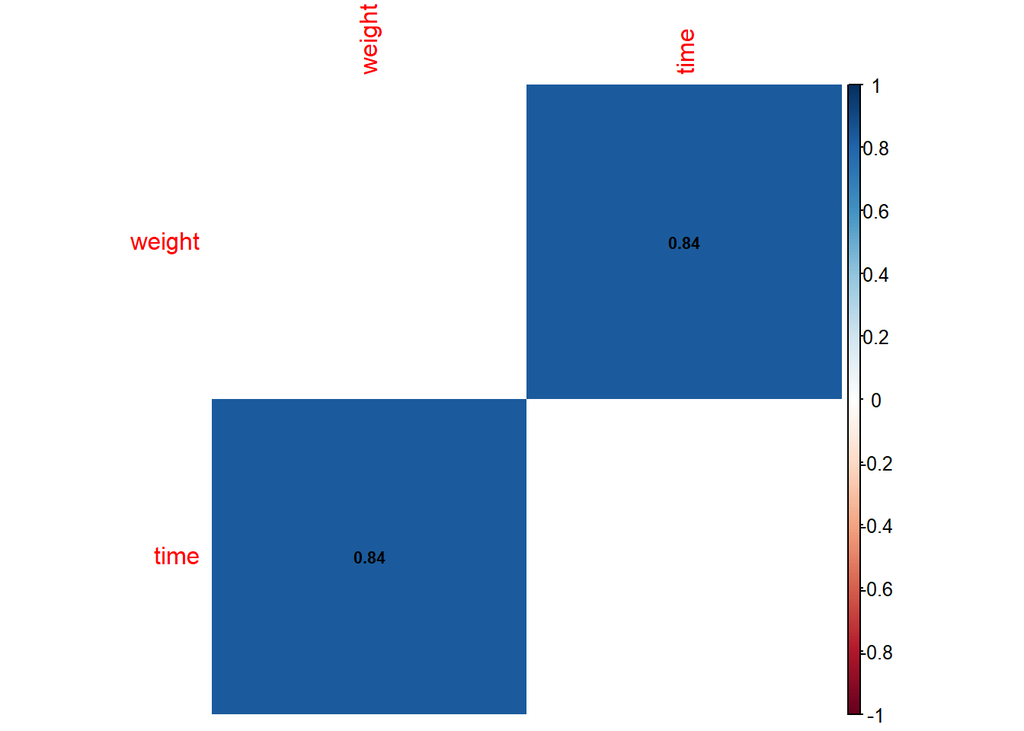

```r
library(corrplot)
DataCor <- DataChick |>
  select(weight, time)
CorMatrix <- cor(DataCor)

corrplot(CorMatrix, method = 'shade', type = 'full',
         addCoef.col ='black', number.cex = 0.7, order = 'original',
         diag = FALSE)
```

# 6 Analysis

## 6.1 First Machine Learning Model: Linear Regression

A linear regression model is fit to predict `weight` using `time` and `diet` as predictors:

```r
ModelOLS <- lm(weight ~ time + diet, data = DataChick)
summary(ModelOLS)
```

```
Call:
lm(formula = weight ~ time + diet, data = DataChick)

Residuals:
     Min       1Q   Median       3Q      Max
-136.851  -17.151   -2.595   15.033  141.816

Coefficients:
            Estimate Std. Error t value Pr(>|t|)
(Intercept)  10.9244     3.3607   3.251  0.00122 **
time          8.7505     0.2218  39.451  < 2e-16 ***
diet2        16.1661     4.0858   3.957 8.56e-05 ***
diet3        36.4994     4.0858   8.933  < 2e-16 ***
diet4        30.2335     4.1075   7.361 6.39e-13 ***
---
Signif. codes:  0 '***' 0.001 '**' 0.01 '*' 0.05 '.' 0.1 ' ' 1

Residual standard error: 35.99 on 573 degrees of freedom
Multiple R-squared:  0.7453,    Adjusted R-squared:  0.7435
F-statistic: 419.2 on 4 and 573 DF,  p-value: < 2.2e-16
```

## 6.2 Second Machine Learning Model: Random Forest

A random forest model is trained to compare with the linear regression:

```r
library(tidymodels)
library(ranger)
set.seed(123)
rf_spec <- rand_forest(mtry = 2, trees = 500, min_n = 5) |>
  set_engine("ranger") |>
  set_mode("regression")

rf_recipe <- recipe(weight ~ time + diet, data = DataChick)

rf_workflow <- workflow() |>
  add_recipe(rf_recipe) |>
  add_model(rf_spec)

rf_fit <- rf_workflow |>
  fit(data = DataChick)
```

```r
library(yardstick)
rf_results <- rf_fit |>
  predict(new_data = DataChick) |>
  bind_cols(DataChick) |>
  metrics(truth = weight, estimate = .pred)
rf_results
```

```
# A tibble: 3 × 3
  .metric .estimator .estimate
  <chr>   <chr>          <dbl>
1 rmse    standard      33.0
2 rsq     standard       0.783
3 mae     standard      20.2
```

# 7 Summary

## 7.1 Linear Regression Results

The linear regression model demonstrates the following: - **Coefficients**: - `time`: A significant positive relationship with weight (β = 8.75, p < 0.001), indicating weight increases with time. - `diet2`, `diet3`, and `diet4`: All positively influence weight compared to the reference diet (p < 0.001), with varying magnitudes. - **Model Fit**: - ( R^2 = 0.745 ), indicating 74.5% of the variance in weight is explained by the predictors. - Residual standard error: 35.99.

Time positively impacts weight, reflecting expected growth over days. The choice of diet significantly affects weight gain, with `diet3` showing the highest positive impact.

## 7.2 Random Forest Results

The random forest results are: - **Metrics**: - RMSE: 33.0 - ( R^2 = 0.783 ) - MAE: 20.2

The random forest model slightly outperforms linear regression in explaining the variance (( R^2 = 78.3% )) and reduces error (lower RMSE and MAE), capturing more complex relationships.

## 7.3 Final Comparison and Choice

The random forest model is chosen as the better model for this analysis based on its higher ( R^2 ), lower RMSE, and better performance in capturing non-linear relationships. However, linear regression remains valuable for its interpretability, especially in understanding individual predictors’ effects.